# Data Visualization Project Plan

Jing Ye, Yiqing Jin, Denis Tan

28 February 2015

# Topic: Energy Demand Forecasting

## Research Question

We hope to visualize current energy demand and forecast future energy demand for various cities worldwide by using time series data on existing hour demand and other publicly available factor variables. We are considering various models, such as time series methods, machine learning methods, econometric methods, to apply and have not settled on a set methodology yet.

## Data Source

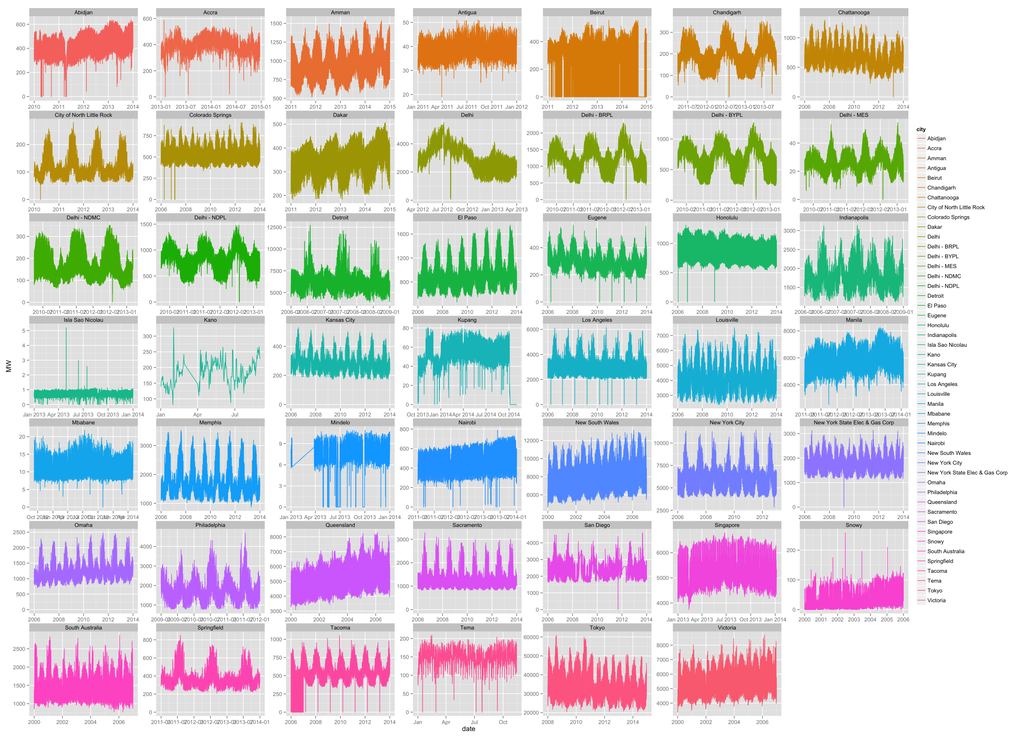

## Team

Our team comprises of 3 members from different backgrounds

- Yiqian Jin (yj2342@columbia.edu): Operations Research

  ```
  - Primary responsibility: Modelling

  - Secondary responsibility: Visualization
  ```

- Jing Ye (jy2674@columbia.edu): Operations Research

  ```
  - Primary responsibility: Modelling

  - Secondary responsibility: Visualization
  ```

- Denis Tan (dwt2118@columbia.edu): Environmental Policy, Engineering and Economics

  ```
  - Primary responsibility: Cleaning Data, Drafting of Report

  - Secondary responsibility: Visualization
  ```

## Potential Conferences for Submission

Our project can potentially submitted to the following conferences

- 2016 IEEE POWER & ENERGY SOCIETY GENERAL MEETING
- The 8th International Conference on Applied Energy (ICAE2016)
- 2nd International Conference on Power and Energy Systems Engineering (2015)

## Workplan

The team will meet weekly on Wednesdays from 2.30pm to 4pm. A draft workplan has been devised

- By March 4th: Clean data (Denis), Models shortlisting (Jing Ye & Yiqian Jin), Conceptualizing visualizations to aspire to (All)
- March 4th to March 30th: Complete Modelling, Finalized List of Visualizations to be done.
- April 1st to April 15th : Complete Visualizations and draft of report / paper.
- Late April: Presentation in Data Visualization Class.